# Image Compression Web Site

## 3. Image 3 Analysis

### 3.1 Load Image

```r
library(readr)
x3 <- read_csv("image3.csv")
x3 <- data.matrix(x3)
```

### 3.2 Original Image

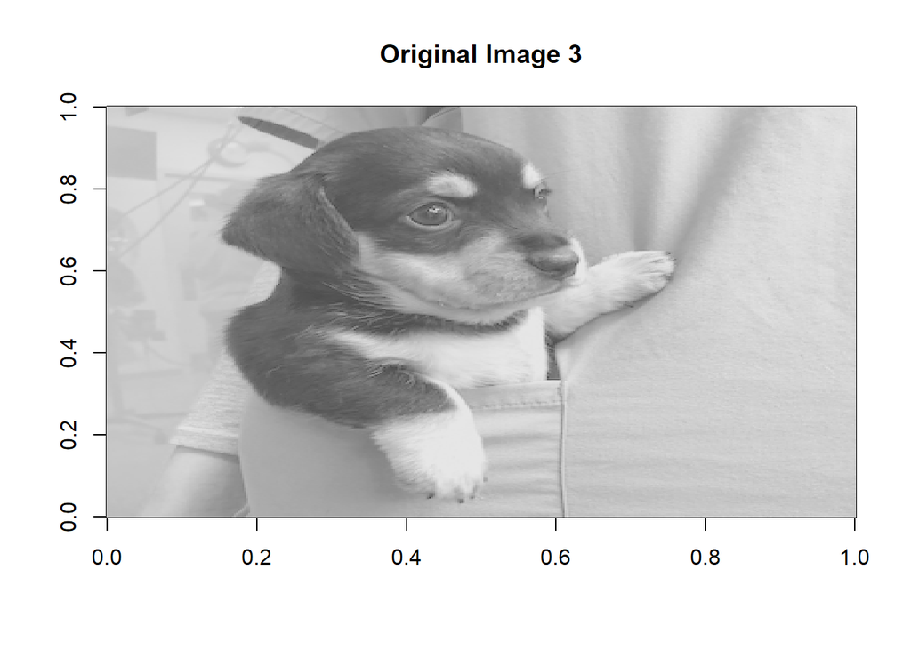

```r
image(x3, col = gray.colors(256), main = "Original Image 3")
```

### 3.3 PCA Approximations (k = 1 to 10)

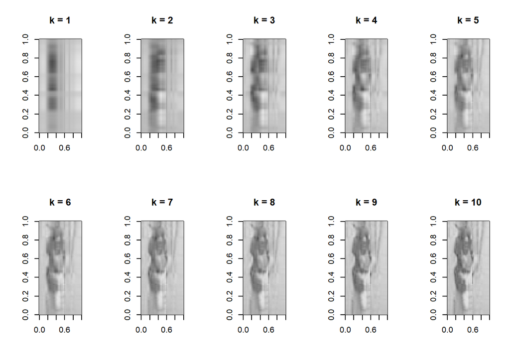

```r
par(mfrow = c(2,5))
for (k in 1:10) {
  result <- compress_image_eigen(x3, k)
  image(result$approx, col = gray.colors(256),
        main = paste("k =", k))
}
```

```r
par(mfrow = c(1,1))
```

### 3.4 A plot of the approximation error vs. k for all possible values of k

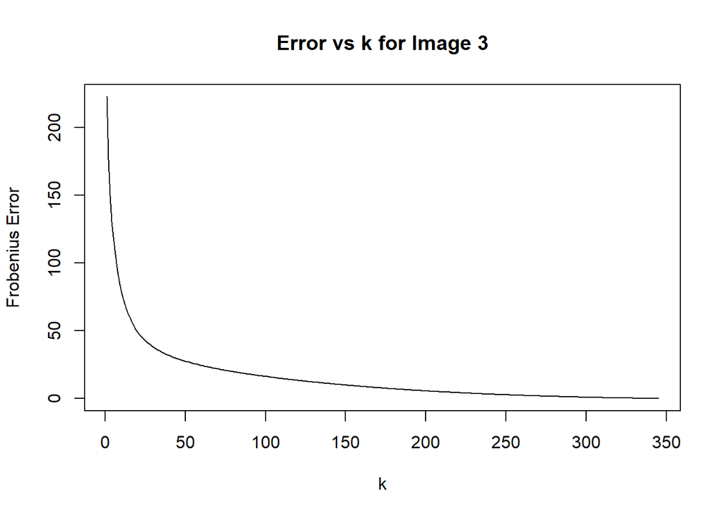

```r
errors <- numeric()

for (k in 1:ncol(x3)) {
  errors[k] <- compress_image_eigen(x3, k)$error
}

plot(errors, type = "l",
     xlab = "k", ylab = "Frobenius Error",
     main = "Error vs k for Image 3")
```

### 3.5 First Eigenvector Plot and First PC Score Plot

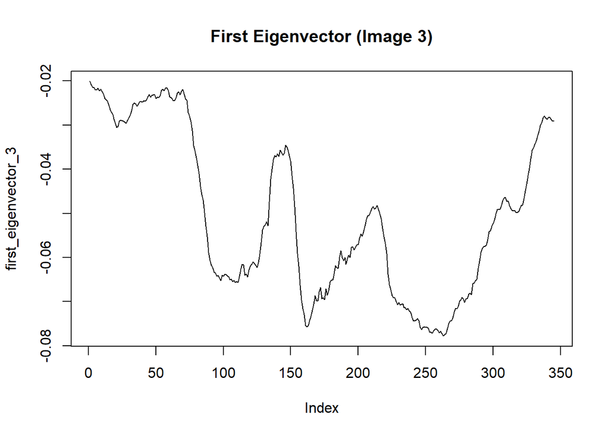

```r
# Compute X'X
V3 <- t(x3) %*% x3

# Eigendecomposition
eig3 <- eigen(V3)

# First eigenvector
first_eigenvector_3 <- eig3$vectors[,1]

# First PC score
first_pc_score_3 <- x3 %*% eig3$vectors[,1]

plot(first_eigenvector_3, type = "l", main = "First Eigenvector (Image 3)")
```

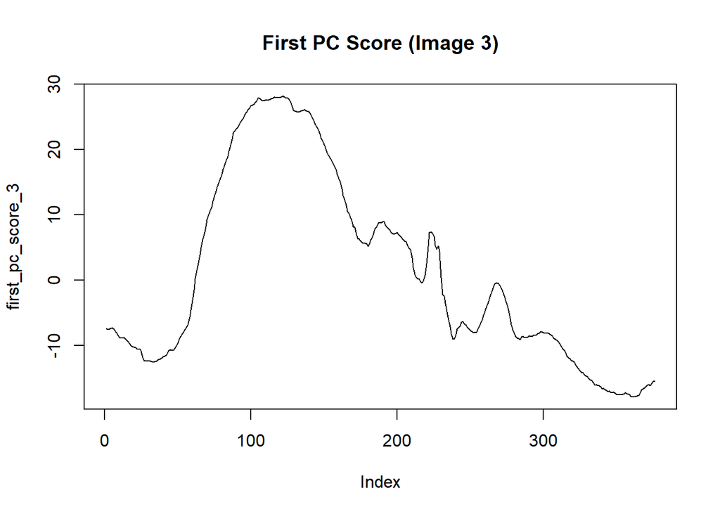

```r
plot(first_pc_score_3, type = "l", main = "First PC Score (Image 3)")
```

**Interpretation of Plots**

The first eigenvector plot shows broad peaks and valleys, indicating gradual intensity changes across the image rather than sharp edges. This pattern corresponds to the smooth lighting and shading on the dog’s body and the surrounding fabric. The first PC score plot rises and falls gently across rows, showing that brightness varies smoothly from one side of the image to the other. Together, these plots reveal that the image is dominated by soft horizontal gradients and natural shading typical of a real photo. Small k PCA captures the dog’s overall shape and lighting, while larger k values refine the fur texture and background details.

## 4. Image 4 Analysis

### 4.1 Load Image

```r
library(readr)
x4 <- read_csv("image4.csv")
x4 <- data.matrix(x4)
```

### 4.2 Original Image

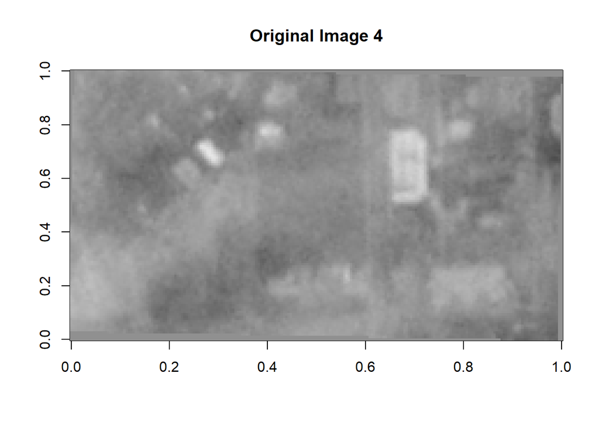

```r
image(x4, col = gray.colors(256), main = "Original Image 4")
```

### 4.3 PCA Approximations (k = 1 to 10)

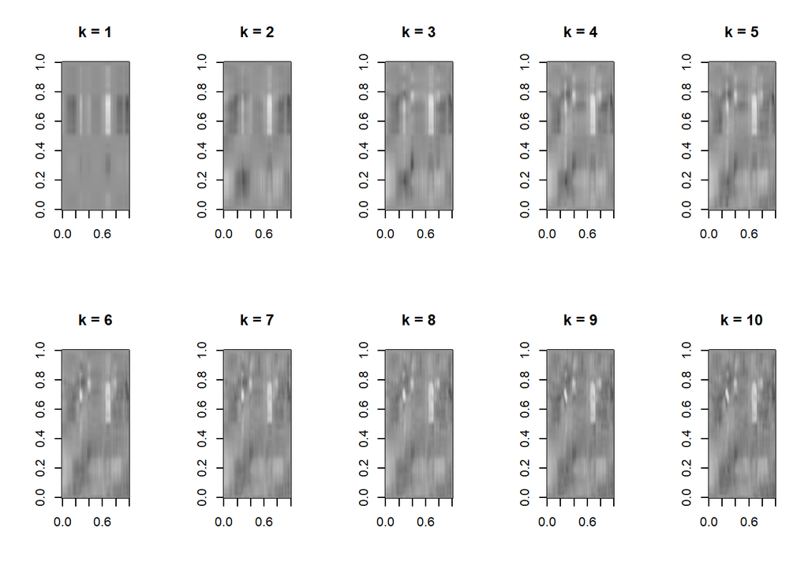

```r
par(mfrow = c(2,5))
for (k in 1:10) {
  result <- compress_image_eigen(x4, k)
  image(result$approx, col = gray.colors(256),
        main = paste("k =", k))
}
```

```r
par(mfrow = c(1,1))
```

### 4.4 A plot of the approximation error vs. k for all possible values of k

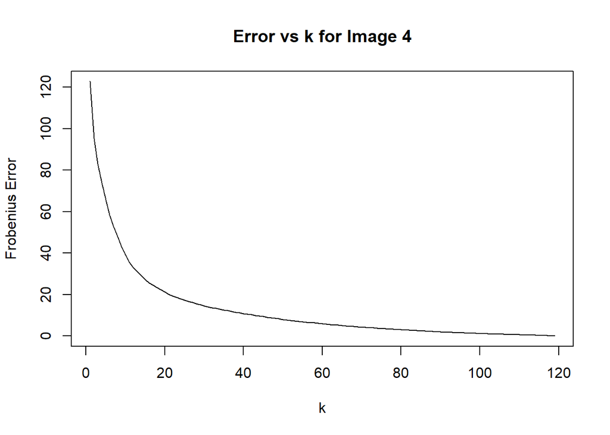

```r
errors <- numeric()

for (k in 1:ncol(x4)) {
  errors[k] <- compress_image_eigen(x4, k)$error
}

plot(errors, type = "l",
     xlab = "k", ylab = "Frobenius Error",
     main = "Error vs k for Image 4")
```